# Modeling Product #3

### More exploration

```r
library(dplyr)

small_group <- df %>%
  filter(UNIT_SALES < 3300, DOLLAR_SALES < 3200)

skim(small_group)
```

Data summary

| Name | small_group |
| --- | --- |
| Number of rows | 2372840 |
| Number of columns | 13 |
| _______________________ |  |
| Column type frequency: |  |
| character | 9 |
| numeric | 4 |
| ________________________ |  |
| Group variables | None |

**Variable type: character**

| skim_variable | n_missing | complete_rate | min | max | empty | n_unique | whitespace |
| --- | --- | --- | --- | --- | --- | --- | --- |
| MARKET_KEY | 0 | 1 | 1 | 4 | 0 | 200 | 0 |
| DATE | 0 | 1 | 10 | 10 | 0 | 152 | 0 |
| CATEGORY | 0 | 1 | 3 | 18 | 0 | 5 | 0 |
| MANUFACTURER | 0 | 1 | 5 | 8 | 0 | 8 | 0 |
| BRAND | 0 | 1 | 4 | 56 | 0 | 288 | 0 |
| PACKAGE | 0 | 1 | 11 | 26 | 0 | 95 | 0 |
| ITEM | 0 | 1 | 26 | 142 | 0 | 2999 | 0 |
| REGION | 0 | 1 | 5 | 11 | 0 | 11 | 0 |
| SEASON | 0 | 1 | 4 | 6 | 0 | 4 | 0 |

**Variable type: numeric**

| skim_variable | n_missing | complete_rate | mean | sd | p0 | p25 | p50 | p75 | p100 | hist |
| --- | --- | --- | --- | --- | --- | --- | --- | --- | --- | --- |
| CALORIC_SEGMENT | 0 | 1 | 0.50 | 0.50 | 0.00 | 0.00 | 0.00 | 1.00 | 1.00 | ▇▁▁▁▇ |
| UNIT_SALES | 0 | 1 | 104.83 | 183.49 | 0.04 | 10.00 | 38.00 | 113.00 | 3298.00 | ▇▁▁▁▁ |
| DOLLAR_SALES | 0 | 1 | 332.69 | 516.65 | 0.01 | 34.92 | 126.27 | 380.55 | 3199.98 | ▇▁▁▁▁ |
| MONTH | 0 | 1 | 6.28 | 3.44 | 1.00 | 3.00 | 6.00 | 9.00 | 12.00 | ▇▆▆▅▇ |

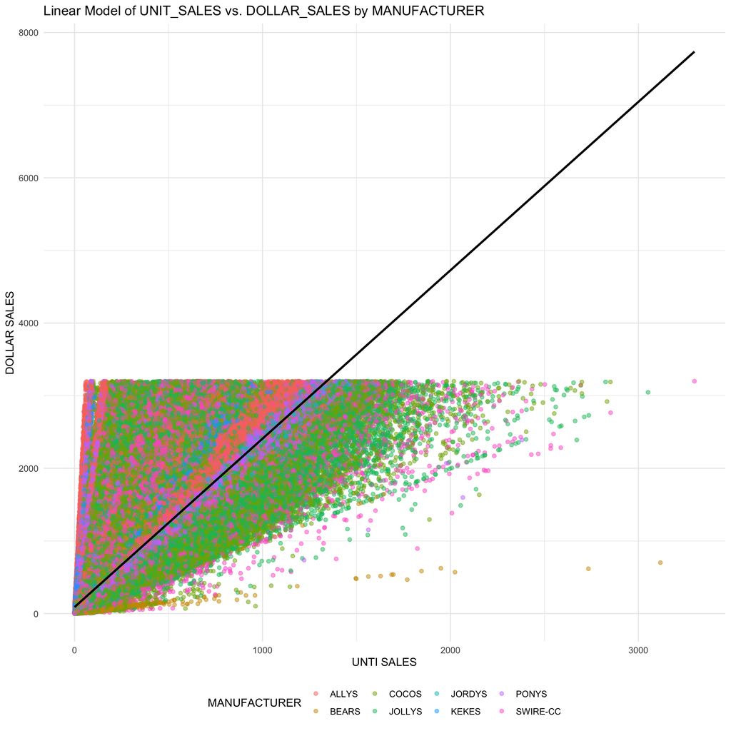

```r
# Create a scatter plot with the regression line, colored by MANUFACTURER
ggplot(small_group, aes(x = UNIT_SALES, y = DOLLAR_SALES, color = MANUFACTURER)) +
  geom_point(alpha = 0.5) +  # Adjust alpha to avoid overplotting, if necessary
  geom_smooth(method = "lm", color = "black", se = FALSE) +  # Add linear regression line without confidence band for clarity
  labs(title = "Linear Model of UNIT_SALES vs. DOLLAR_SALES by MANUFACTURER",
       x = "UNTI SALES",
       y = "DOLLAR SALES") +
  theme_minimal() +
  theme(legend.position = "bottom")  # Adjust legend position if needed
```

> Basically this is where Venomous Blast lives in this realm. Notice still that certain items just sell way better than others in terms of dollars.

#Make the small Kiwanao df > Create a Kiwano Small Data set

```r
kiwano_small <- df[grep("kiwano", df$ITEM, ignore.case = TRUE), ]
```

```r
skim(kiwano_small)
```

Data summary

| Name | kiwano_small |
| --- | --- |
| Number of rows | 71256 |
| Number of columns | 13 |
| _______________________ |  |
| Column type frequency: |  |
| character | 9 |
| numeric | 4 |
| ________________________ |  |
| Group variables | None |

**Variable type: character**

| skim_variable | n_missing | complete_rate | min | max | empty | n_unique | whitespace |
| --- | --- | --- | --- | --- | --- | --- | --- |
| MARKET_KEY | 0 | 1 | 1 | 4 | 0 | 200 | 0 |
| DATE | 0 | 1 | 10 | 10 | 0 | 152 | 0 |
| CATEGORY | 0 | 1 | 3 | 18 | 0 | 4 | 0 |
| MANUFACTURER | 0 | 1 | 5 | 8 | 0 | 7 | 0 |
| BRAND | 0 | 1 | 5 | 41 | 0 | 27 | 0 |
| PACKAGE | 0 | 1 | 12 | 23 | 0 | 28 | 0 |
| ITEM | 0 | 1 | 46 | 105 | 0 | 68 | 0 |
| REGION | 0 | 1 | 5 | 11 | 0 | 11 | 0 |
| SEASON | 0 | 1 | 4 | 6 | 0 | 4 | 0 |

**Variable type: numeric**

| skim_variable | n_missing | complete_rate | mean | sd | p0 | p25 | p50 | p75 | p100 | hist |
| --- | --- | --- | --- | --- | --- | --- | --- | --- | --- | --- |
| CALORIC_SEGMENT | 0 | 1 | 0.34 | 0.48 | 0.00 | 0.00 | 0.0 | 1.00 | 1.00 | ▇▁▁▁▅ |
| UNIT_SALES | 0 | 1 | 101.93 | 384.04 | 0.50 | 8.00 | 26.0 | 76.00 | 16851.00 | ▇▁▁▁▁ |
| DOLLAR_SALES | 0 | 1 | 280.74 | 1016.57 | 0.01 | 28.25 | 86.8 | 221.68 | 45991.65 | ▇▁▁▁▁ |
| MONTH | 0 | 1 | 6.32 | 3.44 | 1.00 | 3.00 | 6.0 | 9.00 | 12.00 | ▇▆▆▅▇ |

```r
# Assuming 'innovation' is your data frame
model <- lm(DOLLAR_SALES ~ UNIT_SALES + CALORIC_SEGMENT + PACKAGE + CATEGORY + SEASON + REGION, data = kiwano_small)
summary(model)
```

```
##
## Call:
## lm(formula = DOLLAR_SALES ~ UNIT_SALES + CALORIC_SEGMENT + PACKAGE +
##     CATEGORY + SEASON + REGION, data = kiwano_small)
##
## Residuals:
##     Min      1Q  Median      3Q     Max
## -4689.1   -40.8    -5.9    38.3  6971.0
##
## Coefficients:
##                                  Estimate Std. Error  t value Pr(>|t|)
## (Intercept)                     1.393e+02  1.103e+01   12.625  < 2e-16 ***
## UNIT_SALES                      2.568e+00  1.992e-03 1288.714  < 2e-16 ***
## CALORIC_SEGMENT                 1.117e+02  2.414e+00   46.279  < 2e-16 ***
## PACKAGE.5L 6ONE JUG            -8.551e+01  6.049e+00  -14.137  < 2e-16 ***
## PACKAGE.5L MULTI JUG           -1.233e+02  1.111e+01  -11.092  < 2e-16 ***
## PACKAGE1.25L MULTI JUG         -3.811e+02  2.084e+01  -18.287  < 2e-16 ***
## PACKAGE12SMALL 12ONE CUP       -8.777e+01  9.668e+00   -9.079  < 2e-16 ***
## PACKAGE12SMALL 24ONE CUP       -2.348e+02  1.484e+01  -15.825  < 2e-16 ***
## PACKAGE12SMALL 8ONE CUP        -8.347e+01  1.062e+01   -7.857 4.00e-15 ***
## PACKAGE12SMALL MLT BUMPY CUP   -1.712e+02  7.514e+00  -22.790  < 2e-16 ***
## PACKAGE12SMALL MLT MEDIUM CUP  -1.833e+02  4.247e+01   -4.317 1.58e-05 ***
## PACKAGE12SMALL MULTI CUP       -1.020e+02  1.107e+01   -9.209  < 2e-16 ***
## PACKAGE16SMALL 12ONE CUP       -1.417e+02  2.247e+01   -6.308 2.85e-10 ***
## PACKAGE16SMALL 24ONE CUP        3.268e+01  1.338e+01    2.442 0.014617 *
## PACKAGE16SMALL 4ONE CUP        -8.254e+01  1.206e+01   -6.842 7.86e-12 ***
## PACKAGE16SMALL MULTI CUP       -2.411e+02  1.079e+01  -22.335  < 2e-16 ***
## PACKAGE18SMALL 6ONE            -3.718e+01  5.306e+00   -7.007 2.46e-12 ***
## PACKAGE18SMALL MULTI JUG       -1.642e+02  4.463e+00  -36.784  < 2e-16 ***
## PACKAGE1L MULTI JUG            -1.883e+02  2.070e+01   -9.096  < 2e-16 ***
## PACKAGE20SMALL 12ONE JUG       -2.342e+02  6.947e+01   -3.371 0.000749 ***
## PACKAGE20SMALL MULTI JUG       -2.175e+02  4.431e+00  -49.091  < 2e-16 ***
## PACKAGE24 - 25SMALL MULTI JUG  -1.819e+02  5.587e+00  -32.557  < 2e-16 ***
## PACKAGE24SMALL MLT SHADYES JUG -1.985e+02  4.364e+01   -4.548 5.42e-06 ***
## PACKAGE2L MULTI JUG            -2.168e+02  7.749e+00  -27.981  < 2e-16 ***
## PACKAGE7.5SMALL 10ONE          -1.313e+02  1.064e+02   -1.234 0.217097
## PACKAGE8SMALL 12ONE CUP        -3.811e+00  1.199e+01   -0.318 0.750544
## PACKAGE8SMALL 24ONE CUP        -2.551e+02  2.122e+01  -12.022  < 2e-16 ***
## PACKAGE8SMALL 4ONE CUP         -1.213e+02  1.151e+01  -10.540  < 2e-16 ***
## PACKAGE8SMALL MULTI CUP        -3.477e+02  1.148e+01  -30.292  < 2e-16 ***
```

[output cut: 8 more lines]

```
## REGIONCOLORADO                  1.046e+01  2.480e+00    4.220 2.45e-05 ***
## REGIONDESERT_SW                 2.392e+00  2.934e+00    0.815 0.414922
## REGIONKANSAS                    1.757e+02  5.232e+00   33.571  < 2e-16 ***
## REGIONMOUNTAIN                  1.032e+01  2.691e+00    3.835 0.000126 ***
## REGIONNEWMEXICO                 1.735e+01  3.511e+00    4.943 7.71e-07 ***
## REGIONNOCAL                     2.368e+00  3.761e+00    0.630 0.528893
## REGIONNORTHERN                  8.657e+00  2.026e+00    4.273 1.93e-05 ***
## REGIONPRAIRIE                   2.289e+01  4.318e+00    5.301 1.15e-07 ***
## REGIONSOCAL                     1.705e+00  2.842e+00    0.600 0.548662
## ---
## Signif. codes:  0 '***' 0.001 '**' 0.01 '*' 0.05 '.' 0.1 ' ' 1
##
## Residual standard error: 183.4 on 71210 degrees of freedom
## Multiple R-squared:  0.9675, Adjusted R-squared:  0.9675
## F-statistic: 4.707e+04 on 45 and 71210 DF,  p-value: < 2.2e-16
```

## Create redefined KIWANO set for modeling

```r
kiwano_small <- df %>%
  filter(CATEGORY == "ENERGY",
         str_detect(ITEM, "KIWANO"),
         CALORIC_SEGMENT == 0,
          str_detect(PACKAGE, "16"))
```

> Rework kiwanao for more features for XGboost Model

```r
kiwano_small <- kiwano_small %>%
  mutate(
    PACKAGE2 = str_extract(ITEM, "(CUP|JUG).*"),  # Extracts the part from CUP or JUG to the end.
    ITEM = str_replace(ITEM, "(CUP|JUG).*", "")  # Replaces the CUP/JUG and everything after it with empty string in ITEM.
  )
```

```r
kiwano_small <- kiwano_small %>%
  mutate(
    TEMP = str_extract(ITEM, "\\d+\\.?\\d*.*"), # Extracts the part from the first number to the end.
    PACKAGE2 = if_else(is.na(PACKAGE2), TEMP, paste(PACKAGE2, TEMP)), # Combines existing PACKAGE2 with new extraction if needed.
    ITEM = str_replace(ITEM, "\\d+\\.?\\d*.*", ""), # Removes the numeric part and everything after it from ITEM.
    TEMP = NULL  # Removes the temporary column.
  )
```

```r
na_rows <- kiwano_small %>%
  filter(is.na(PACKAGE2))
#na_rows
#the above steps excised all packaging out of ITEM column
```

```r
kiwano_small <- kiwano_small %>%
  mutate(
    GENTLE_DRINK = if_else(str_detect(ITEM, "GENTLE DRINK"), 1, 0), # Assigns 1 if "GENTLE DRINK" exists, otherwise 0.
    ITEM = str_replace(ITEM, "GENTLE DRINK", "") # Removes "GENTLE DRINK" from ITEM.
  )
```

```r
kiwano_small <- kiwano_small %>%
  mutate(
    ENERGY_DRINK = if_else(str_detect(ITEM, "ENERGY DRINK"), 1, 0), # Assigns 1 if "ENERGY DRINK" exists, otherwise 0.
    ITEM = str_replace(ITEM, "ENERGY DRINK", "") # Removes "ENERGY DRINK" from ITEM.
  )
```

```r
library(stringr)
# Define the pattern as a regular expression
pattern <- "ZERO CALORIES|ZERO CALORIE|ZERO SUGAR|SUGAR FREE|NO CALORIES"

kiwano_small <- kiwano_small %>%
  mutate(
    CALORIC_SEGMENT_TEXT = str_extract(ITEM, pattern), # Extracts matching text based on the pattern.
    ITEM = str_replace_all(ITEM, pattern, "") # Removes extracted text from ITEM.
  )
```

```r
kiwano_small <- kiwano_small %>%
  mutate(
    CALORIC_SEGMENT_TEXT = if_else(str_detect(ITEM, "\\bDIET\\b"),
                                   if_else(is.na(CALORIC_SEGMENT_TEXT), "DIET", paste(CALORIC_SEGMENT_TEXT, "DIET", sep=", ")),
                                   CALORIC_SEGMENT_TEXT)
  )
```

```r
# Function to remove the second instance of any repeating word
remove_second_instance <- function(item) {
  words <- unlist(str_split(item, "\\s+")) # Split item into words
  unique_words <- unique(words) # Get unique words to check for repeats
  for (word in unique_words) {
    word_indices <- which(words == word) # Find all indices of the current word
    if (length(word_indices) > 1) { # If there is more than one occurrence
      words[word_indices[2]] <- "" # Remove the second occurrence
    }
  }
  return(paste(words, collapse = " ")) # Reconstruct sentence without the second instance
}

# Apply the function to the 'ITEM' column
kiwano_small <- kiwano_small %>%
  mutate(ITEM = sapply(ITEM, remove_second_instance))


# Remove specific columns
kiwano_small <- select(kiwano_small, -PACKAGE2, -GENTLE_DRINK, -ENERGY_DRINK, -CALORIC_SEGMENT_TEXT)
```

```r
head(kiwano_small)
```

```
##   MARKET_KEY       DATE CALORIC_SEGMENT CATEGORY UNIT_SALES DOLLAR_SALES
## 1        504 2022-02-26               0   ENERGY         11        78.89
## 2        953 2022-08-20               0   ENERGY         13        21.83
## 3        133 2020-12-19               0   ENERGY         20        40.55
## 4        817 2022-02-05               0   ENERGY        194       287.06
## 5        733 2022-05-07               0   ENERGY          8        63.42
## 6        754 2023-05-13               0   ENERGY        176       258.79
##   MANUFACTURER                     BRAND           PACKAGE
## 1        PONYS   MYTHICAL BEVERAGE ULTRA  16SMALL 4ONE CUP
## 2       JOLLYS     SUPER-DUPER PURE ZERO 16SMALL MULTI CUP
## 3       JOLLYS HILL MOISTURE JUMPIN-FISH 16SMALL MULTI CUP
## 4       JOLLYS     SUPER-DUPER PURE ZERO 16SMALL MULTI CUP
## 5        PONYS   MYTHICAL BEVERAGE ULTRA  16SMALL 4ONE CUP
## 6       JOLLYS     SUPER-DUPER PURE ZERO 16SMALL MULTI CUP
##                                                       ITEM    REGION MONTH
## 1               MYTHICAL BEVERAGE ULTRA KIWANO UNFLAVORED   NORTHERN     2
## 2                       SUPER-DUPER PURE ZERO KIWANO KEKE    ARIZONA     8
## 3 RAINING JUMPIN-FISH GAME FUEL ZERO CHARGED KIWANO SHOCK   MOUNTAIN    12
## 4                       SUPER-DUPER PURE ZERO KIWANO KEKE   COLORADO     2
## 5               MYTHICAL BEVERAGE ULTRA KIWANO UNFLAVORED    ARIZONA     5
## 6                       SUPER-DUPER PURE ZERO KIWANO KEKE  DESERT_SW     5
##   SEASON
## 1 WINTER
## 2 SUMMER
## 3 WINTER
## 4 WINTER
## 5 SPRING
## 6 SPRING
```

```r
write.csv(kiwano_small, "kiwano_small.csv", row.names = FALSE)
```

# FINAL THOUGHTS

> Though Kiwano and energy drinks have very few rows. I do think there is potential here to find a good fitting model that can predict launch sales. I am thinking that if we can get a model that will predict the sales of uints of energy drinks, with size 16, and kiwano flavor we can then use that combined with the current sales rate of VENOMUS BLAST launches to get an accurate forecast. As far as selection of what weeks would be best to sell I don’t see any other way than by using historical best 13 weeks sales of either Venmous Blast, energy drinks, or kiwano flavored drinks.

# XGBoost

```r
# Set up
if (!require("pacman")) install.packages("pacman")
pacman::p_load(tidyverse, skimr, knitr, caret, readr,
               ggplot2, dplyr, tidymodels, pROC, xgboost, doParallel, vip, DALEXtra)
```

## Create One Hot Encoded DF for Model

```r
# Read the CSV file
kiwano_small <- read.csv("kiwano_small.csv")

# Convert 'Date' column to Date format
kiwano_small$DATE <- as.Date(kiwano_small$DATE)

# List to store unique values for each variable
unique_values_list <- list()

# Columns to get unique values for
columns_to_get_unique_values <- c("BRAND", "PACKAGE", "ITEM", "REGION", "SEASON")

# Get unique values for each variable and store in the list
for (col in columns_to_get_unique_values) {
  unique_values_list[[col]] <- unique(kiwano_small[[col]])
}

# Loop over unique regions and create new columns
for (region in unique_values_list$REGION) {
  kiwano_small[[region]] <- as.integer(grepl(region, kiwano_small$REGION))
}

# Loop over unique brands and create new columns
for (brand in unique_values_list$BRAND) {
  kiwano_small[[brand]] <- as.integer(grepl(brand, kiwano_small$BRAND))
}

# Loop over unique brands and create new columns
for (item in unique_values_list$ITEM) {
  kiwano_small[[item]] <- as.integer(grepl(item, kiwano_small$ITEM))
}

# Loop over unique regions and create new columns
for (package in unique_values_list$PACKAGE) {
  kiwano_small[[package]] <- as.integer(grepl(package, kiwano_small$PACKAGE))
}

# Loop over unique regions and create new columns
for (season in unique_values_list$SEASON) {
  kiwano_small[[season]] <- as.integer(grepl(season, kiwano_small$SEASON))
}

# Add new columns for week since launch and week of the year
kiwano_small <- kiwano_small %>%
  mutate(
    Week_Of_Year = week(DATE)
  ) %>%
  group_by(ITEM) %>%
  mutate(
    Week_Since_Launch = as.integer((DATE - min(DATE)) / 7) + 1
  ) %>%
  ungroup()  # Ungroup the data to ensure the next operation applies to the entire data frame

# Remove unnecessary columns
one_hot_kiwano <- kiwano_small %>%
  select(-MARKET_KEY, -CALORIC_SEGMENT, -CATEGORY, -MANUFACTURER, -BRAND, -REGION, -PACKAGE, -SEASON, -ITEM)

head(one_hot_kiwano)
```

```
## # A tibble: 6 × 38
##   DATE       UNIT_SALES DOLLAR_SALES MONTH NORTHERN ARIZONA MOUNTAIN COLORADO
##   <date>          <dbl>        <dbl> <int>    <int>   <int>    <int>    <int>
## 1 2022-02-26         11         78.9     2        1       0        0        0
## 2 2022-08-20         13         21.8     8        0       1        0        0
## 3 2020-12-19         20         40.6    12        0       0        1        0
## 4 2022-02-05        194        287.      2        0       0        0        1
## 5 2022-05-07          8         63.4     5        0       1        0        0
## 6 2023-05-13        176        259.      5        0       0        0        0
## # ℹ 30 more variables: DESERT_SW <int>, NOCAL <int>, SOCAL <int>, KANSAS <int>,
## #   NEWMEXICO <int>, CALI_NEVADA <int>, PRAIRIE <int>,
## #   `MYTHICAL BEVERAGE ULTRA` <int>, `SUPER-DUPER PURE ZERO` <int>,
## #   `HILL MOISTURE JUMPIN-FISH` <int>, `VENOMOUS BLAST` <int>, `POW-POW` <int>,
## #   `MYTHICAL BEVERAGE REHAB` <int>,
## #   `MYTHICAL BEVERAGE ULTRA KIWANO UNFLAVORED ` <int>,
## #   `SUPER-DUPER PURE ZERO KIWANO KEKE ` <int>, …
```

```r
write.csv(one_hot_kiwano, "one_hot_kiwano.csv", row.names = FALSE)
```

## Load and Prepare the data

```r
# Load and prepare dataset
df1 <- read.csv("one_hot_kiwano.csv")
df1 <- df1 %>%
  select(-DATE, -MONTH, -WINTER, -SPRING, -FALL, -DOLLAR_SALES, -SUMMER)
```

```r
# Summarize the dataset
skimr::skim(df1)
```

Data summary

| Name | df1 |
| --- | --- |
| Number of rows | 8082 |
| Number of columns | 31 |
| _______________________ |  |
| Column type frequency: |  |
| numeric | 31 |
| ________________________ |  |
| Group variables | None |

**Variable type: numeric**

| skim_variable | n_missing | complete_rate | mean | sd | p0 | p25 | p50 | p75 | p100 | hist |
| --- | --- | --- | --- | --- | --- | --- | --- | --- | --- | --- |
| UNIT_SALES | 0 | 1 | 171.20 | 468.61 | 0.5 | 10 | 66 | 214 | 10621 | ▇▁▁▁▁ |
| NORTHERN | 0 | 1 | 0.25 | 0.43 | 0.0 | 0 | 0 | 0 | 1 | ▇▁▁▁▂ |
| ARIZONA | 0 | 1 | 0.21 | 0.41 | 0.0 | 0 | 0 | 0 | 1 | ▇▁▁▁▂ |
| MOUNTAIN | 0 | 1 | 0.10 | 0.29 | 0.0 | 0 | 0 | 0 | 1 | ▇▁▁▁▁ |
| COLORADO | 0 | 1 | 0.12 | 0.32 | 0.0 | 0 | 0 | 0 | 1 | ▇▁▁▁▁ |
| DESERT_SW | 0 | 1 | 0.07 | 0.26 | 0.0 | 0 | 0 | 0 | 1 | ▇▁▁▁▁ |
| NOCAL | 0 | 1 | 0.04 | 0.20 | 0.0 | 0 | 0 | 0 | 1 | ▇▁▁▁▁ |
| SOCAL | 0 | 1 | 0.09 | 0.28 | 0.0 | 0 | 0 | 0 | 1 | ▇▁▁▁▁ |
| KANSAS | 0 | 1 | 0.02 | 0.14 | 0.0 | 0 | 0 | 0 | 1 | ▇▁▁▁▁ |
| NEWMEXICO | 0 | 1 | 0.04 | 0.20 | 0.0 | 0 | 0 | 0 | 1 | ▇▁▁▁▁ |
| CALI_NEVADA | 0 | 1 | 0.04 | 0.19 | 0.0 | 0 | 0 | 0 | 1 | ▇▁▁▁▁ |
| PRAIRIE | 0 | 1 | 0.03 | 0.17 | 0.0 | 0 | 0 | 0 | 1 | ▇▁▁▁▁ |
| MYTHICAL.BEVERAGE.ULTRA | 0 | 1 | 0.55 | 0.50 | 0.0 | 0 | 1 | 1 | 1 | ▆▁▁▁▇ |
| SUPER.DUPER.PURE.ZERO | 0 | 1 | 0.37 | 0.48 | 0.0 | 0 | 0 | 1 | 1 | ▇▁▁▁▅ |
| HILL.MOISTURE.JUMPIN.FISH | 0 | 1 | 0.04 | 0.19 | 0.0 | 0 | 0 | 0 | 1 | ▇▁▁▁▁ |
| VENOMOUS.BLAST | 0 | 1 | 0.03 | 0.17 | 0.0 | 0 | 0 | 0 | 1 | ▇▁▁▁▁ |
| POW.POW | 0 | 1 | 0.01 | 0.10 | 0.0 | 0 | 0 | 0 | 1 | ▇▁▁▁▁ |
| MYTHICAL.BEVERAGE.REHAB | 0 | 1 | 0.00 | 0.02 | 0.0 | 0 | 0 | 0 | 1 | ▇▁▁▁▁ |
| MYTHICAL.BEVERAGE.ULTRA.KIWANO.UNFLAVORED. | 0 | 1 | 0.55 | 0.50 | 0.0 | 0 | 1 | 1 | 1 | ▆▁▁▁▇ |
| SUPER.DUPER.PURE.ZERO.KIWANO.KEKE. | 0 | 1 | 0.30 | 0.46 | 0.0 | 0 | 0 | 1 | 1 | ▇▁▁▁▃ |
| RAINING.JUMPIN.FISH.GAME.FUEL.ZERO.CHARGED.KIWANO.SHOCK. | 0 | 1 | 0.04 | 0.19 | 0.0 | 0 | 0 | 0 | 1 | ▇▁▁▁▁ |
| SUPER.DUPER.PURE.ZERO.KIWANO. | 0 | 1 | 0.37 | 0.48 | 0.0 | 0 | 0 | 1 | 1 | ▇▁▁▁▅ |
| VENOMOUS.BLAST.KIWANO.DURIAN. | 0 | 1 | 0.03 | 0.17 | 0.0 | 0 | 0 | 0 | 1 | ▇▁▁▁▁ |
| POW.POW.WYLDIN.KIWANO. | 0 | 1 | 0.01 | 0.10 | 0.0 | 0 | 0 | 0 | 1 | ▇▁▁▁▁ |
| MYTHICAL.BEVERAGE.REHAB.KIWANO. | 0 | 1 | 0.00 | 0.02 | 0.0 | 0 | 0 | 0 | 1 | ▇▁▁▁▁ |
| X16SMALL.4ONE.CUP | 0 | 1 | 0.15 | 0.36 | 0.0 | 0 | 0 | 0 | 1 | ▇▁▁▁▂ |
| X16SMALL.MULTI.CUP | 0 | 1 | 0.77 | 0.42 | 0.0 | 1 | 1 | 1 | 1 | ▂▁▁▁▇ |
| X16SMALL.24ONE.CUP | 0 | 1 | 0.07 | 0.25 | 0.0 | 0 | 0 | 0 | 1 | ▇▁▁▁▁ |
| X16SMALL.12ONE.CUP | 0 | 1 | 0.01 | 0.10 | 0.0 | 0 | 0 | 0 | 1 | ▇▁▁▁▁ |
| Week_Of_Year | 0 | 1 | 25.13 | 15.37 | 1.0 | 12 | 24 | 39 | 53 | ▇▇▆▆▆ |
| Week_Since_Launch | 0 | 1 | 65.58 | 40.11 | 1.0 | 29 | 66 | 99 | 152 | ▇▆▇▆▂ |

```r
#Remove outliers in top 1% of Unit Sales.
df1 <- df1 %>% filter(UNIT_SALES < quantile(UNIT_SALES, 0.99))
```

```r
# Split the data
set.seed(123)
df_testtrn <- initial_split(df1, prop = 0.8, strata = UNIT_SALES)
Train <- training(df_testtrn)
Test <- testing(df_testtrn)

# Prepare features and labels for XGBoost
train_features <- Train[, -which(names(Train) == "UNIT_SALES")]
train_labels <- Train$UNIT_SALES
test_features <- Test[, -which(names(Test) == "UNIT_SALES")]
test_labels <- Test$UNIT_SALES

# Convert data to DMatrix format
dtrain <- xgb.DMatrix(data = as.matrix(train_features), label = train_labels)
dtest <- xgb.DMatrix(data = as.matrix(test_features), label = test_labels)
```

```r
# Define XGBoost parameters
set.seed(123)
params <- list(
  booster = "gbtree",
  objective = "reg:squarederror",
  eval_metric = "rmse",
  eta = 0.05,
  max_depth = 4,
  min_child_weight = 3,
  subsample = 0.7,
  colsample_bytree = 0.6,
  lambda = 1,
  alpha = 1
)
```

```r
# Perform cross-validation to find the optimal number of boosting rounds
cv_results <- xgb.cv(
  params = params,
  data = dtrain,
  nfold = 5,
  nrounds = 500,  # Changed from 'num_boost_round' to 'nrounds'
  early_stopping_rounds = 10,
  metrics = "rmse",
  seed = 123
)
```

[output not shown]

```r
best_nrounds <- cv_results$best_iteration
```

# Create Model

```r
# Train the final model using the best number of rounds found
model_xgb <- xgb.train(
  params = params,
  data = dtrain,
  nrounds = best_nrounds
)
```

# Setup Train and Test

```r
# Make predictions and evaluate the model
train_pred <- predict(model_xgb, dtrain)
test_pred <- predict(model_xgb, dtest)
train_rmse <- sqrt(mean((train_labels - train_pred)^2))
test_rmse <- sqrt(mean((test_labels - test_pred)^2))
```

# Create Model Metrics

```r
# Calculate R-squared for the training set
sst_train <- sum((train_labels - mean(train_labels)) ^ 2)
ssr_train <- sum((train_labels - train_pred) ^ 2)
r_squared_train <- 1 - (ssr_train / sst_train)

# Calculate R-squared for the test set
sst_test <- sum((test_labels - mean(test_labels)) ^ 2)
ssr_test <- sum((test_labels - test_pred) ^ 2)
r_squared_test <- 1 - (ssr_test / sst_test)

train_mape <- mean(abs((train_labels - train_pred) / train_labels)) * 100
test_mape <- mean(abs((test_labels - test_pred) / test_labels)) * 100
train_mae <- mean(abs(train_labels - train_pred))
test_mae <- mean(abs(test_labels - test_pred))
```

# Output Results

```r
cat("Model Performance Metrics:\n",
    "--------------------------\n",
    "Training RMSE: ", train_rmse, "\n",
    "Test RMSE: ", test_rmse, "\n",
    "Training R-squared: ", r_squared_train, "\n",
    "Test R-squared: ", r_squared_test, "\n",
    "Training MAE: ", train_mae, "\n",
    "Test MAE: ", test_mae, "\n",
    "Training MAPE: ", train_mape, "%\n",
    "Test MAPE: ", test_mape, "%\n", sep="")
```

```
## Model Performance Metrics:
## --------------------------
## Training RMSE: 100.2922
## Test RMSE: 109.3214
## Training R-squared: 0.6834959
## Test R-squared: 0.6279935
## Training MAE: 59.00142
## Test MAE: 62.41945
## Training MAPE: 232.4294%
## Test MAPE: 224.7447%
```

```r
# Calculate feature importance
importance_matrix2 <- xgb.importance(feature_names = colnames(train_features), model = model_xgb)

# View the feature importance scores
print(importance_matrix2)
```

```
##                                                      Feature         Gain
##  1:                                  MYTHICAL.BEVERAGE.ULTRA 3.304469e-01
##  2:                                       X16SMALL.MULTI.CUP 1.587434e-01
##  3:                                        X16SMALL.4ONE.CUP 8.550262e-02
##  4:               MYTHICAL.BEVERAGE.ULTRA.KIWANO.UNFLAVORED. 8.428400e-02
##  5:                                       X16SMALL.24ONE.CUP 7.729816e-02
##  6:                                        Week_Since_Launch 7.542692e-02
##  7:                                                  PRAIRIE 3.223505e-02
##  8:                                                 COLORADO 3.033846e-02
##  9:                       SUPER.DUPER.PURE.ZERO.KIWANO.KEKE. 2.614484e-02
## 10:                                                   KANSAS 1.719257e-02
## 11:                                                    NOCAL 1.450320e-02
## 12:                                             Week_Of_Year 1.412197e-02
## 13:                                                 NORTHERN 8.905549e-03
## 14:                                    SUPER.DUPER.PURE.ZERO 7.738604e-03
```

[output cut: 45 more lines]

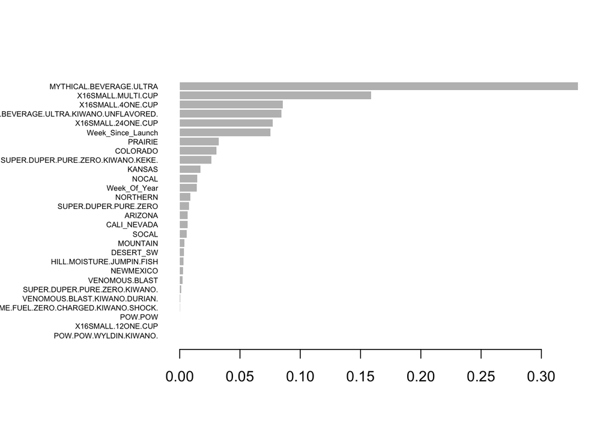

```r
xgb.plot.importance(importance_matrix = importance_matrix2)
```

>From this Importance matrix we see that brand and size seem to be the two biggest contributors to our model. We also see that the created featrure Week_Since_Launche is playing a large part in the creation of predictions.

## Create Dummy Data and attempt prediction

```r
# Define vectors for each category
regions <- 1:11
brands <- 1:6
items <- 1:7
package_options <- 1:4

# Create data frame with all combinations of categories
combinations <- expand.grid(Region = regions, Brand = brands, Item = items, Package = package_options)

# Duplicate each combination 52 times to represent each week of the year
final_df_replicated <- combinations[rep(row.names(combinations), each = 52), ]

# Add a column with values from 1 to 52 for each combination
final_df_replicated$Week_of_Year <- rep(1:52, times = nrow(combinations))

# Duplicate each combination 52 times to represent each week of the year
final_df_replicated <- final_df_replicated[rep(row.names(final_df_replicated), each = 13), ]

# Add a column with values from 1 to 13 for each combination
final_df_replicated$Week_Since_Launch <- rep(1:13, times = nrow(combinations))

final_df_replicated$Region <- unique_values_list$REGION[final_df_replicated$Region]
final_df_replicated$Brand <- unique_values_list$BRAND[final_df_replicated$Brand]
final_df_replicated$Item <- unique_values_list$ITEM[final_df_replicated$Item]
final_df_replicated$Package <- unique_values_list$PACKAGE[final_df_replicated$Package]

# List to store unique values for each variable
new_unique_values_list <- list()

# Columns to get unique values for
new_columns_to_get_unique_values <- c("Region", "Brand", "Item", "Package")

# Get unique values for each variable and store in the list
for (col in new_columns_to_get_unique_values) {
  new_unique_values_list[[col]] <- unique(final_df_replicated[[col]])
}

# Loop over unique regions and create new columns
for (Region in new_unique_values_list$Region) {
  final_df_replicated[[Region]] <- as.integer(final_df_replicated$Region == Region)
}

# Loop over unique regions and create new columns
for (Brand in new_unique_values_list$Brand) {
  final_df_replicated[[Brand]] <- as.integer(final_df_replicated$Brand == Brand)
}

# Loop over unique regions and create new columns
for (Item in new_unique_values_list$Item) {
  final_df_replicated[[Item]] <- as.integer(final_df_replicated$Item == Item)
}

# Loop over unique regions and create new columns
for (Package in new_unique_values_list$Package) {
  final_df_replicated[[Package]] <- as.integer(final_df_replicated$Package == Package)
}

#Create dummy_data and remove non one hot encoded data
dummy_data <- final_df_replicated %>%
  select(-Region, -Brand, -Item, -Package)

#add a Unit sales column
dummy_data$UNIT_SALES <- NA
dummy_data$UNIT_SALES <- as.numeric(dummy_data$UNIT_SALES)
```

## Assure Features are Matching and Predict

```r
#rename columes to match original features
dummy_data <- dummy_data %>%
  rename(
    `MYTHICAL.BEVERAGE.ULTRA` = `MYTHICAL BEVERAGE ULTRA`,
    `SUPER.DUPER.PURE.ZERO` = `SUPER-DUPER PURE ZERO`,
    `HILL.MOISTURE.JUMPIN.FISH` = `HILL MOISTURE JUMPIN-FISH`,
    `VENOMOUS.BLAST` = `VENOMOUS BLAST`,
    `POW.POW` = `POW-POW`,
    `MYTHICAL.BEVERAGE.REHAB` = `MYTHICAL BEVERAGE REHAB`,
    `MYTHICAL.BEVERAGE.ULTRA.KIWANO.UNFLAVORED.` = `MYTHICAL BEVERAGE ULTRA KIWANO UNFLAVORED `,
    `SUPER.DUPER.PURE.ZERO.KIWANO.KEKE.` = `SUPER-DUPER PURE ZERO KIWANO KEKE `,
    `RAINING.JUMPIN.FISH.GAME.FUEL.ZERO.CHARGED.KIWANO.SHOCK.` = `RAINING JUMPIN-FISH GAME FUEL ZERO CHARGED KIWANO SHOCK `,
    `SUPER.DUPER.PURE.ZERO.KIWANO.` = `SUPER-DUPER PURE ZERO KIWANO `,
    `VENOMOUS.BLAST.KIWANO.DURIAN.` = `VENOMOUS BLAST KIWANO DURIAN `,
    `POW.POW.WYLDIN.KIWANO.` = `POW-POW WYLDIN KIWANO `,
    `MYTHICAL.BEVERAGE.REHAB.KIWANO.` = `MYTHICAL BEVERAGE REHAB KIWANO `,
    `X16SMALL.4ONE.CUP` = `16SMALL 4ONE CUP`,
    `X16SMALL.MULTI.CUP` = `16SMALL MULTI CUP`,
    `X16SMALL.24ONE.CUP` = `16SMALL 24ONE CUP`,
    `X16SMALL.12ONE.CUP` = `16SMALL 12ONE CUP`,
    `Week_Of_Year`  = `Week_of_Year`
  )

# Check for Matching Features
#Get the column names of Test and dummy_data
names_Test <- names(Test)
names_dummy_data <- names(dummy_data)

# Find the matching column names
matching_names <- intersect(names_Test, names_dummy_data)

# Find the non-matching column names
non_matching_names_Test <- setdiff(names_Test, matching_names)
non_matching_names_dummy_data <- setdiff(names_dummy_data, matching_names)

#Print the matching and non-matching column names
cat("Matching column names:", paste(matching_names, collapse = ", "), "\n")
```

```
## Matching column names: UNIT_SALES, NORTHERN, ARIZONA, MOUNTAIN, COLORADO, DESERT_SW, NOCAL, SOCAL, KANSAS, NEWMEXICO, CALI_NEVADA, PRAIRIE, MYTHICAL.BEVERAGE.ULTRA, SUPER.DUPER.PURE.ZERO, HILL.MOISTURE.JUMPIN.FISH, VENOMOUS.BLAST, POW.POW, MYTHICAL.BEVERAGE.REHAB, MYTHICAL.BEVERAGE.ULTRA.KIWANO.U…
```

```r
cat("Non-matching column names in Test:", paste(non_matching_names_Test, collapse = ", "), "\n")
```

```
## Non-matching column names in Test:
```

```r
cat("Non-matching column names in dummy_data:", paste(non_matching_names_dummy_data, collapse = ", "), "\n")
```

```
## Non-matching column names in dummy_data:
```

```r
# Get the column names of the Test dataframe
test_colnames <- colnames(Test)

# Reorder columns of dummy_data to match the order of columns in Test
dummy_data <- dummy_data %>%
  select(all_of(test_colnames))

# Prepare features for XGBoost
dummy_features <- dummy_data[, -which(names(dummy_data) == "UNIT_SALES")]

# Convert data to DMatrix format
dummy_dmatrix<- xgb.DMatrix(data = as.matrix(dummy_features))

dummy_pred <- predict(model_xgb, dummy_dmatrix)

# Add the predictions to dummy_data
dummy_data$Predictions <- dummy_pred

# Convert predictions to integers
dummy_data$Predictions <- round(dummy_pred)

# Convert to integer data type
dummy_data$Predictions <- as.integer(dummy_data$Predictions)

summary(dummy_data$Predictions)
```

```
##    Min. 1st Qu.  Median    Mean 3rd Qu.    Max.
##  -73.00  -22.00   -6.00   21.07   31.00  658.00
```

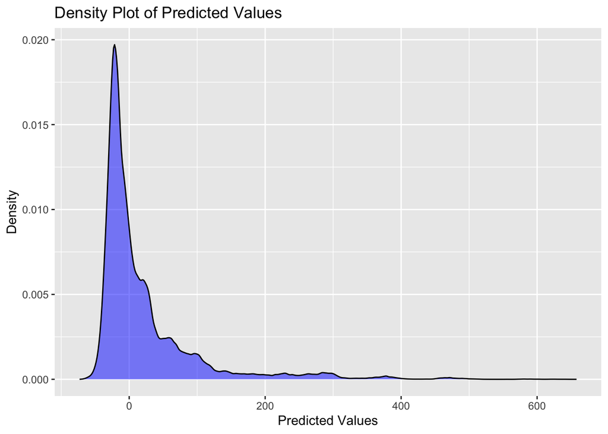

```r
ggplot(dummy_data, aes(x = Predictions)) +
  geom_density(fill = "blue", alpha = 0.5) +
  labs(title = "Density Plot of Predicted Values",
       x = "Predicted Values",
       y = "Density")
```

```r
dummy_data %>%
  group_by(Week_Since_Launch, Week_Of_Year) %>%
  summarize(Total_Prediction = sum(Predictions, na.rm = TRUE))%>%
  filter(Week_Since_Launch <=13,
         Week_Of_Year <=24)
```

```
## # A tibble: 312 × 3
## # Groups:   Week_Since_Launch [13]
##    Week_Since_Launch Week_Of_Year Total_Prediction
##                <int>        <int>            <int>
##  1                 1            1            13114
##  2                 1            2            14329
##  3                 1            3            20001
##  4                 1            4            26952
##  5                 1            5            11969
##  6                 1            6            12265
##  7                 1            7            10152
##  8                 1            8             1138
##  9                 1            9             2919
## 10                 1           10            -2271
## # ℹ 302 more rows
```

> In this first round of predcition we attempted to have our model predict a value for every combination of Item, Region, Brand, and Package, Week of the year and week since launch (1-13) from our comparable data report. The model will need some refinement as it is predicting many negative values, but once tuned this could provide a way to make comparable predictions of a new product launching for 13 weeks in any range during the year.